# Homework3 predict flight delay

Linsui Deng 2019000152

Yonghua Su 2019000154

Maoyu Zhang 2019000157

2019/10/4

## Analysis of the flight delay data

### Pre-treat data

We library relevant packages, read the data and transform them into data.table form firstly.

```r
library(MASS)
library(rpart)
library(randomForest)
library(pROC)
library(data.table)

flight <- read.csv("flights.csv",colClasses=c("YEAR" = "character", "DEPARTURE_TIME" = "character",
                                              "MONTH" = "character", "WHEELS_OFF" = "character",
                                              "DAY" = "character", "ORIGIN_AIRPORT" = "character",
                                              "SCHEDULED_DEPARTURE" = "character", "WHEELS_ON" = "character",
                                              "SCHEDULED_ARRIVAL" = "character", "ARRIVAL_TIME" = "character"))
flight <- as.data.table(flight)

flights2 <- flight
rm(flight)
```

Unlike before, we select all analyzable columns without preferences and 16 columns are selected.

```r
#Select col
select_col <- c("MONTH", "DAY", "DAY_OF_WEEK",
                "AIRLINE", "ORIGIN_AIRPORT", "DESTINATION_AIRPORT", "SCHEDULED_DEPARTURE",
                "DEPARTURE_TIME", "DEPARTURE_DELAY", "TAXI_OUT", "SCHEDULED_TIME",
                "ELAPSED_TIME", "AIR_TIME", "DISTANCE", "TAXI_IN", "ARRIVAL_DELAY")
flights2 <- flights2[, select_col, with=F]

# nan
flights2 <- na.omit(flights2, invert = F)

flights2 <- flights2[is.na(as.numeric(flights2$ORIGIN_AIRPORT)),] #numeric airport id. should be deleted.
```

We want to convert arilines, airports, months, days of month, days of week and etcs into dummy variables. However, there are nearly 300 airports and if we take them into consideration, the memory is full, so we delete it. (However, we can try to classify the airport to solve this problem.)

The departure time influence the delay largely, whereas the departure time doesn’t have meanings itself. Therefore, we split the departure time into three classes: 0~8, 8~16, 16~24.

```r
# dummy variable
library(nnet)
month_mat <- class.ind(flights2$MONTH)
colnames(month_mat) <- paste("month_", colnames(month_mat), sep = '')

day_mat <- class.ind(flights2$DAY)
colnames(day_mat) <- paste("day_", colnames(day_mat), sep = '')

day_of_week_mat <- class.ind(flights2$DAY_OF_WEEK)
colnames(day_of_week_mat) <- paste("day_of_week_", colnames(day_of_week_mat), sep = '')

airline_mat <- class.ind(flights2$AIRLINE)
colnames(airline_mat) <- paste("airline_", colnames(airline_mat), sep = '')

## SCHEDULED_DEPARTURE
flights2$SCHEDULED_DEPARTURE <- as.numeric(flights2$SCHEDULED_DEPARTURE)
flights2$is_first_sch_dep <- 0
flights2[between(SCHEDULED_DEPARTURE, 0, 799), is_first_sch_dep := 1 ]

flights2$is_second_sch_dep <- 0
flights2[between(SCHEDULED_DEPARTURE, 800, 1599), is_second_sch_dep := 1]

flights2$is_third_sch_dep <- 0
flights2[between(SCHEDULED_DEPARTURE, 1600, 2359), is_third_sch_dep := 1]

## DEPARTURE_TIME
flights2$DEPARTURE_TIME <- as.numeric(flights2$DEPARTURE_TIME)
flights2$is_first_dep <- 0
flights2[between(DEPARTURE_TIME, 0, 799), is_first_dep := 1]

flights2$is_second_dep <- 0
flights2[between(DEPARTURE_TIME, 800, 1599), is_second_dep := 1]

flights2$is_third_dep <- 0
flights2[between(DEPARTURE_TIME, 1600, 2359), is_third_dep := 1]


flights2 <- cbind(flights2, month_mat, day_mat, day_of_week_mat,
                  airline_mat)
```

Finally, the tail of delay time is heavy, we use logarithm transformation to reduce the heavy tail. Since the part most interested in is the delay part, we only use the data that departure delay and arrival delay is large than zero. To retain the information as more as possible, we substruct the minimal of delay time and take the logarithm transformation.

```r
flights0930_2 <- flights2[,-c(1:8,34:64)]
rm(flights2, day_mat, month_mat, day_of_week_mat, airline_mat)
min_departure <- min(flights0930_2$DEPARTURE_DELAY)
min_arrival <- min(flights0930_2$ARRIVAL_DELAY)
flights0930_2 <- flights0930_2[flights0930_2$DEPARTURE_DELAY>0 & flights0930_2$ARRIVAL_DELAY>0, ]
```

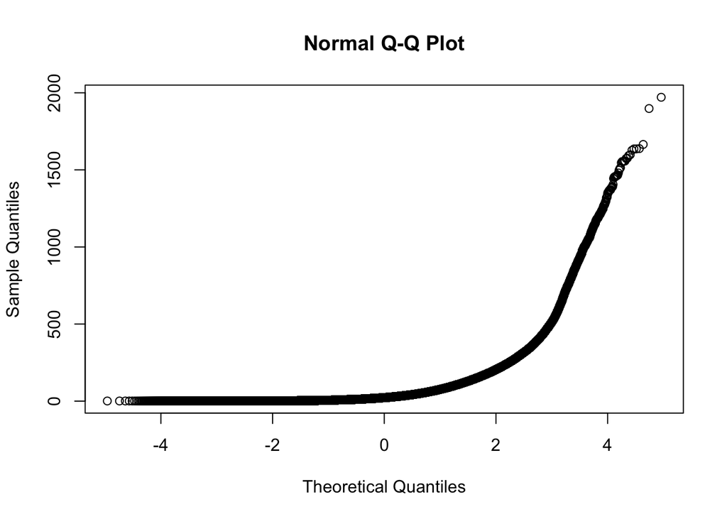

```r
qqnorm(flights0930_2$ARRIVAL_DELAY)
```

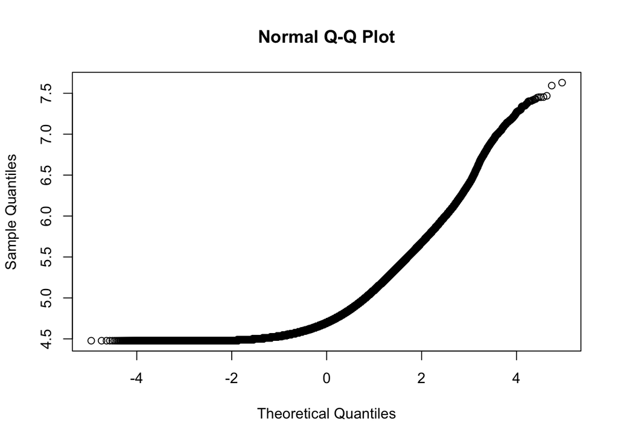

```r
qqnorm(log(flights0930_2$ARRIVAL_DELAY-min_arrival))
```

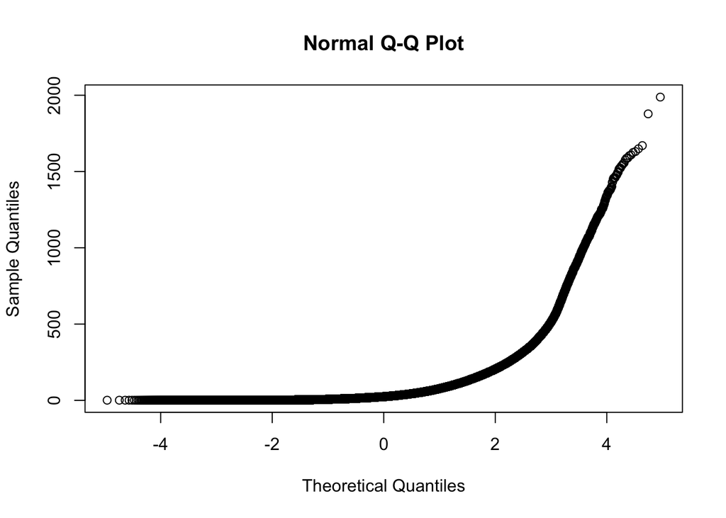

```r
qqnorm(flights0930_2$DEPARTURE_DELAY)
```

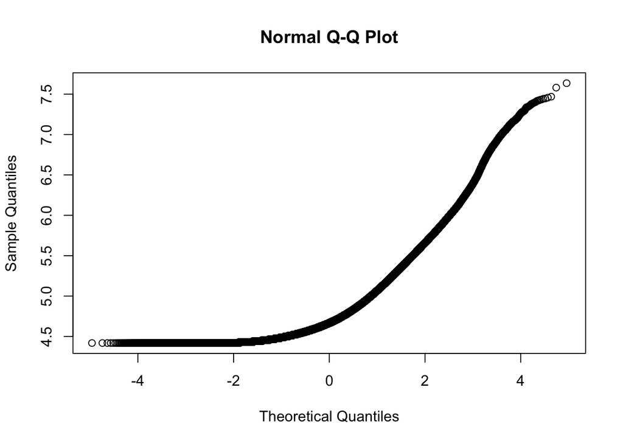

```r
qqnorm(log(flights0930_2$DEPARTURE_DELAY-min_departure))
```

From the Q-Q plot, after taking logrithm, the tail is not such heavy and the data is more suitable for our analysis. Therefore, we transform the data.

```r
# step1, step2
flights0930_2$DEPARTURE_DELAY=log(flights0930_2$DEPARTURE_DELAY-min_departure)
flights0930_2[, 2:7] = log(flights0930_2[, 2:7])
flights0930_2$ARRIVAL_DELAY=log(flights0930_2$ARRIVAL_DELAY-min_arrival)
```

After that, we extract the training set and the testing set.

```r
train = sample(c(T,F),nrow(flights0930_2),rep=T)
test = !train
```

### Linear Model and Variable Selection

In this part, we use simple linear regression to predict flight delay as response and then use backward and forward selection to identify the most relevant predictors.

```r
# step3
fit1 <- lm(ARRIVAL_DELAY~.,data = flights0930_2[train,])
summary(fit1)
```

```
##
## Call:
## lm(formula = ARRIVAL_DELAY ~ ., data = flights0930_2[train, ])
##
## Residuals:
##      Min       1Q   Median       3Q      Max
## -0.66691 -0.02209 -0.00390  0.01880  0.65843
##
## Coefficients: (4 not defined because of singularities)
##                     Estimate Std. Error  t value Pr(>|t|)
## (Intercept)        4.024e-01  4.586e-03   87.748  < 2e-16 ***
## DEPARTURE_DELAY    9.628e-01  1.946e-04 4948.376  < 2e-16 ***
## TAXI_OUT           5.416e-02  2.293e-04  236.173  < 2e-16 ***
## SCHEDULED_TIME    -8.090e-01  8.157e-04 -991.759  < 2e-16 ***
## ELAPSED_TIME       5.963e-01  1.101e-03  541.813  < 2e-16 ***
## AIR_TIME           2.037e-01  1.060e-03  192.088  < 2e-16 ***
## DISTANCE          -3.977e-02  4.814e-04  -82.611  < 2e-16 ***
## TAXI_IN            2.495e-02  1.408e-04  177.187  < 2e-16 ***
## is_first_sch_dep  -7.251e-03  4.165e-04  -17.409  < 2e-16 ***
## is_second_sch_dep -2.480e-03  2.753e-04   -9.007  < 2e-16 ***
## is_third_sch_dep          NA         NA       NA       NA
## is_first_dep      -7.921e-03  4.357e-03   -1.818 0.069050 .
## is_second_dep     -1.838e-02  4.346e-03   -4.229 2.34e-05 ***
## is_third_dep      -2.170e-02  4.337e-03   -5.003 5.66e-07 ***
## month_1            3.917e-04  3.174e-04    1.234 0.217109
## month_11          -1.605e-04  3.324e-04   -0.483 0.629311
## month_12          -4.353e-04  3.146e-04   -1.384 0.166485
## month_2            1.194e-03  3.179e-04    3.758 0.000171 ***
## month_3            4.671e-04  3.136e-04    1.490 0.136307
## month_4            1.880e-03  3.233e-04    5.817 5.99e-09 ***
## month_5            1.866e-03  3.185e-04    5.859 4.67e-09 ***
## month_6            1.569e-03  3.053e-04    5.140 2.75e-07 ***
## month_7            7.473e-04  3.065e-04    2.438 0.014770 *
## month_8            4.806e-04  3.143e-04    1.529 0.126224
## month_9                   NA         NA       NA       NA
## day_of_week_1      5.499e-04  2.249e-04    2.445 0.014496 *
## day_of_week_2      9.577e-04  2.296e-04    4.171 3.03e-05 ***
## day_of_week_3      1.665e-04  2.294e-04    0.726 0.467955
## day_of_week_4      7.000e-04  2.245e-04    3.118 0.001822 **
## day_of_week_5     -7.624e-05  2.268e-04   -0.336 0.736751
## day_of_week_6      6.898e-04  2.489e-04    2.772 0.005575 **
## day_of_week_7             NA         NA       NA       NA
## airline_AA        -7.014e-03  2.371e-04  -29.578  < 2e-16 ***
## airline_AS         2.261e-03  4.424e-04    5.111 3.20e-07 ***
## airline_B6        -1.144e-03  3.124e-04   -3.661 0.000251 ***
## airline_DL        -7.758e-03  2.330e-04  -33.291  < 2e-16 ***
## airline_EV        -4.347e-03  2.490e-04  -17.459  < 2e-16 ***
## airline_F9        -1.424e-03  4.588e-04   -3.104 0.001910 **
## airline_HA        -1.281e-02  5.971e-04  -21.451  < 2e-16 ***
## airline_MQ        -5.199e-03  3.127e-04  -16.624  < 2e-16 ***
## airline_NK         3.196e-04  3.873e-04    0.825 0.409321
## airline_OO        -4.865e-03  2.520e-04  -19.302  < 2e-16 ***
## airline_UA        -1.309e-02  2.488e-04  -52.591  < 2e-16 ***
## airline_US        -9.997e-04  3.715e-04   -2.691 0.007125 **
## airline_VX         2.077e-03  6.046e-04    3.435 0.000592 ***
## airline_WN                NA         NA       NA       NA
## ---
## Signif. codes:  0 '***' 0.001 '**' 0.01 '*' 0.05 '.' 0.1 ' ' 1
##
## Residual standard error: 0.0513 on 707578 degrees of freedom
## Multiple R-squared:  0.9744, Adjusted R-squared:  0.9744
## F-statistic: 6.563e+05 on 41 and 707578 DF,  p-value: < 2.2e-16
```

The $t$ values of linear regression show these variables are correlated with the delay with high significance. To identify the most relevant predictors, we chose $AIC$ as our criterion and set direction as both. Since we are not going to find a best simple linear regression model but to observe the order of the importance of each predictor, we don’t set the end condition.

```r
fit_step <- stepAIC(fit1,direction="both",trace = FALSE)
summary(fit_step)
```

```
##
## Call:
## lm(formula = ARRIVAL_DELAY ~ DEPARTURE_DELAY + TAXI_OUT + SCHEDULED_TIME +
##     ELAPSED_TIME + AIR_TIME + DISTANCE + TAXI_IN + is_first_sch_dep +
##     is_second_sch_dep + is_first_dep + is_second_dep + is_third_dep +
##     month_1 + month_2 + month_3 + month_4 + month_5 + month_6 +
##     month_7 + month_8 + day_of_week_1 + day_of_week_2 + day_of_week_4 +
##     day_of_week_6 + airline_AA + airline_AS + airline_B6 + airline_DL +
##     airline_EV + airline_F9 + airline_HA + airline_MQ + airline_OO +
##     airline_UA + airline_US + airline_VX, data = flights0930_2[train,
##     ])
##
## Residuals:
##     Min      1Q  Median      3Q     Max
## -0.6669 -0.0221 -0.0039  0.0188  0.6583
##
## Coefficients:
##                     Estimate Std. Error  t value Pr(>|t|)
## (Intercept)        0.4021809  0.0045786   87.839  < 2e-16 ***
## DEPARTURE_DELAY    0.9627548  0.0001943 4955.993  < 2e-16 ***
## TAXI_OUT           0.0541767  0.0002289  236.693  < 2e-16 ***
## SCHEDULED_TIME    -0.8089313  0.0008149 -992.627  < 2e-16 ***
## ELAPSED_TIME       0.5963186  0.0011002  541.992  < 2e-16 ***
## AIR_TIME           0.2036659  0.0010602  192.105  < 2e-16 ***
## DISTANCE          -0.0397591  0.0004812  -82.623  < 2e-16 ***
## TAXI_IN            0.0249641  0.0001402  178.042  < 2e-16 ***
## is_first_sch_dep  -0.0072475  0.0004164  -17.403  < 2e-16 ***
## is_second_sch_dep -0.0024830  0.0002753   -9.018  < 2e-16 ***
## is_first_dep      -0.0079254  0.0043570   -1.819 0.068912 .
## is_second_dep     -0.0183847  0.0043461   -4.230 2.34e-05 ***
## is_third_dep      -0.0217011  0.0043370   -5.004 5.62e-07 ***
## month_1            0.0006064  0.0002397    2.530 0.011404 *
## month_2            0.0014174  0.0002405    5.893 3.80e-09 ***
## month_3            0.0006858  0.0002346    2.923 0.003464 **
## month_4            0.0021020  0.0002477    8.487  < 2e-16 ***
## month_5            0.0020892  0.0002412    8.663  < 2e-16 ***
## month_6            0.0017931  0.0002234    8.028 9.96e-16 ***
## month_7            0.0009760  0.0002254    4.330 1.49e-05 ***
## month_8            0.0007046  0.0002356    2.990 0.002786 **
## day_of_week_1      0.0005198  0.0001802    2.884 0.003927 **
## day_of_week_2      0.0009228  0.0001857    4.970 6.69e-07 ***
## day_of_week_4      0.0006723  0.0001792    3.751 0.000176 ***
## day_of_week_6      0.0006626  0.0002093    3.165 0.001549 **
## airline_AA        -0.0070523  0.0002316  -30.447  < 2e-16 ***
## airline_AS         0.0022286  0.0004403    5.062 4.15e-07 ***
## airline_B6        -0.0011832  0.0003088   -3.832 0.000127 ***
## airline_DL        -0.0077958  0.0002280  -34.186  < 2e-16 ***
## airline_EV        -0.0043764  0.0002453  -17.841  < 2e-16 ***
## airline_F9        -0.0014615  0.0004561   -3.205 0.001352 **
## airline_HA        -0.0128284  0.0005963  -21.514  < 2e-16 ***
## airline_MQ        -0.0052281  0.0003097  -16.879  < 2e-16 ***
## airline_OO        -0.0048990  0.0002483  -19.727  < 2e-16 ***
## airline_UA        -0.0131257  0.0002431  -53.995  < 2e-16 ***
## airline_US        -0.0010373  0.0003685   -2.815 0.004874 **
## airline_VX         0.0020285  0.0006027    3.366 0.000764 ***
## ---
## Signif. codes:  0 '***' 0.001 '**' 0.01 '*' 0.05 '.' 0.1 ' ' 1
##
## Residual standard error: 0.0513 on 707583 degrees of freedom
## Multiple R-squared:  0.9744, Adjusted R-squared:  0.9744
## F-statistic: 7.474e+05 on 36 and 707583 DF,  p-value: < 2.2e-16
```

The order of the importance with respect to this method is revealed in the above sheet. We can find the DEPARTURE_DELAY, SCHEDULED_TIME, ELAPSED_TIME, TAXI_OUT, AIR_TIME, TAXI_IN are the most influential variables.

### Tree Model and Variable Selection

Also, we use tree model to do the same thing. Regression tree model training is fast, the tree diagram is as follows.

```r
# step4
## 回归树
fit_tree <- rpart(ARRIVAL_DELAY~.,data = flights0930_2[train,])
# rpartTrue2=as.party(fit_tree)
```

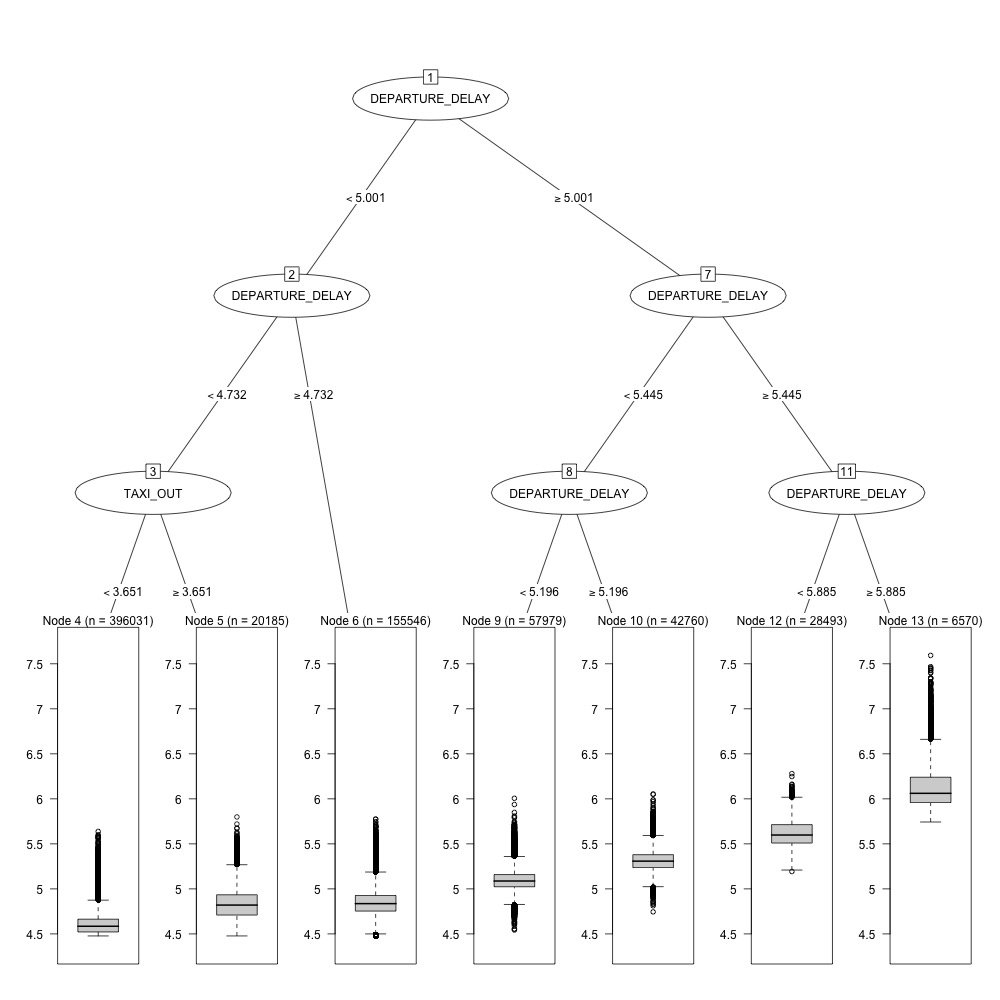

### Random Forest Model and Variable Selection

Similarly, we use random forest model to conduct regression and identify the importance of variables. %IncMSE measures the MSE increasing, which is achieved by assigning a random value to each variable. If this variable is very important, the prediction error will increase, so the increase of error is equal to the decrease of accuracy. Therefore, the larger this value is, the more important this variable is.

IncNodePurity is another index. If the regression is performed, node purity is actually the reduction of RSS (residual sum of squares), and the increase in node purity is equivalent to the reduction of Gini index, that is, the data or classes in the node are the same, which is also Mean Decrease Gini.

```r
## 随机森林
fit_forest <- randomForest(ARRIVAL_DELAY~., data = flights0930_2[sample(1:nrow(flights0930_2), 10000, replace = FALSE),],ntree=100,mtry=5,importance=TRUE, proximity=TRUE)
print(fit_forest$importance)
```

```
##                         %IncMSE IncNodePurity
## DEPARTURE_DELAY    1.317126e-01   641.7352239
## TAXI_OUT           5.289699e-03    46.2099666
## SCHEDULED_TIME     1.566422e-02    24.8595428
## ELAPSED_TIME       2.507199e-02    27.7207237
## AIR_TIME           1.381222e-02    23.9159205
## DISTANCE           1.405167e-02    25.0063859
## TAXI_IN            1.633888e-03    24.8724562
## is_first_sch_dep   1.778439e-02     9.3714954
## is_second_sch_dep  5.426639e-02    18.7753759
## is_third_sch_dep   1.410745e-01    15.2304650
## is_first_dep       1.013000e-02     5.6453548
## is_second_dep      1.223813e-01     8.7517108
## is_third_dep       6.602181e-02    16.4498812
## month_1            1.874582e-06     2.4639002
## month_11          -1.921286e-05     2.5518003
## month_12          -2.028583e-05     2.7083793
## month_2           -8.038072e-05     2.5405068
## month_3           -1.143968e-04     2.6193873
## month_4           -1.239607e-04     2.1784426
## month_5           -1.354703e-04     2.4876854
## month_6           -4.606861e-05     2.9210425
## month_7           -9.925509e-05     2.6722667
## month_8            8.186729e-05     2.5479029
## month_9           -6.405634e-05     2.0683783
## day_of_week_1     -2.834371e-04     3.1880442
## day_of_week_2     -2.548410e-05     2.8254762
## day_of_week_3     -6.925143e-05     2.7246630
## day_of_week_4     -1.986058e-05     2.8215359
## day_of_week_5      3.142555e-05     2.9498593
## day_of_week_6     -1.878569e-05     2.3998129
## day_of_week_7     -1.265638e-04     2.6934341
## airline_AA        -3.451885e-06     2.5640917
## airline_AS         7.158328e-07     0.6800229
## airline_B6        -6.523427e-06     1.9153144
## airline_DL         4.620724e-05     3.0522255
## airline_EV         6.635316e-05     1.7262002
## airline_F9        -5.907386e-05     1.5116226
## airline_HA         4.350234e-04     0.9422046
## airline_MQ         2.888891e-04     2.2569744
## airline_NK        -7.439838e-05     1.4052645
## airline_OO         8.198670e-05     2.6549626
## airline_UA         3.560827e-05     2.5562937
## airline_US        -4.384308e-05     0.9630849
## airline_VX        -1.046795e-05     0.7070445
## airline_WN         9.679552e-04     4.6112305
```

[figure not shown]

```r
#用画图来看变量的重要性
# varImpPlot(fit_forest, main = "variable importance")
```

### Test

Now we use mean square error as the criterion to judge models.

```r
# step5验证
pred1=predict(fit_step,newdata=flights0930_2[test,])
pred2=predict(fit_tree,newdata=flights0930_2[test,])
pred3=predict(fit_forest,newdata=flights0930_2[test,])
result=cbind(pred1,pred2,pred3)
#以均方误差作为评估标准
dif=result-flights0930_2$ARRIVAL_DELAY[test]
mse=apply(dif^2,2,mean)
print(mse)
```

```
##       pred1       pred2       pred3
## 0.002633445 0.012787097 0.012547877
```

```r
##逐步回归的结果明显优于两种树方法，可能是因为树方法做得太粗糙
```

With mean square error, the evaluation standard, we divide the data into training set and testing set to verify the regression results of stepwise regression model, regression tree model and random forest model, and find that stepwise regression model performs significantly better than the other two tree methods, which may be because the tree method was too rough.

### Logistic Regression

```r
# step6
flights0930_2l=flights0930_2[sample(1:nrow(flights0930_2), 10000, replace = FALSE)]
flights0930_2l$ARRIVAL_DELAY[flights0930_2l$ARRIVAL_DELAY<=log(60 - min_arrival)] <- 0
flights0930_2l$ARRIVAL_DELAY[flights0930_2l$ARRIVAL_DELAY>log(60 - min_arrival)] <- 1
```

After that, we are able to conduct the logistics regression.

```r
# step7
fit_full <- glm(ARRIVAL_DELAY~.,family=binomial(link="logit"),data = flights0930_2l)
summary(fit_full)
```

```
##
## Call:
## glm(formula = ARRIVAL_DELAY ~ ., family = binomial(link = "logit"),
##     data = flights0930_2l)
##
## Deviance Residuals:
##     Min       1Q   Median       3Q      Max
## -3.2106  -0.0212  -0.0027  -0.0005   4.1943
##
## Coefficients: (4 not defined because of singularities)
##                     Estimate Std. Error z value Pr(>|z|)
## (Intercept)       -1.513e+02  3.248e+02  -0.466  0.64139
## DEPARTURE_DELAY    2.972e+01  1.156e+00  25.706  < 2e-16 ***
## TAXI_OUT           2.609e+00  2.929e-01   8.908  < 2e-16 ***
## SCHEDULED_TIME    -2.451e+01  1.301e+00 -18.846  < 2e-16 ***
## ELAPSED_TIME       1.590e+01  1.421e+00  11.184  < 2e-16 ***
## AIR_TIME           8.466e+00  1.234e+00   6.858 6.98e-12 ***
## DISTANCE          -1.461e+00  5.549e-01  -2.633  0.00846 **
## TAXI_IN            1.024e+00  1.728e-01   5.923 3.17e-09 ***
## is_first_sch_dep   1.444e-01  4.453e-01   0.324  0.74581
## is_second_sch_dep  3.967e-02  2.944e-01   0.135  0.89281
## is_third_sch_dep          NA         NA      NA       NA
## is_first_dep       6.882e+00  3.247e+02   0.021  0.98309
## is_second_dep      7.530e+00  3.247e+02   0.023  0.98150
## is_third_dep       7.583e+00  3.247e+02   0.023  0.98137
## month_1           -3.136e-01  3.818e-01  -0.821  0.41152
## month_11          -2.452e-01  4.291e-01  -0.572  0.56765
## month_12          -8.387e-01  3.834e-01  -2.188  0.02870 *
## month_2           -3.121e-01  3.949e-01  -0.790  0.42935
## month_3           -1.290e-01  3.948e-01  -0.327  0.74390
## month_4           -2.749e-01  4.041e-01  -0.680  0.49643
## month_5            1.174e-02  3.992e-01   0.029  0.97655
## month_6           -4.845e-02  3.768e-01  -0.129  0.89768
## month_7           -8.692e-02  3.733e-01  -0.233  0.81591
## month_8           -2.817e-02  3.827e-01  -0.074  0.94132
## month_9                   NA         NA      NA       NA
## day_of_week_1      8.617e-02  2.671e-01   0.323  0.74699
## day_of_week_2      3.426e-01  2.682e-01   1.278  0.20134
## day_of_week_3     -2.275e-01  2.832e-01  -0.803  0.42174
## day_of_week_4     -6.100e-02  2.682e-01  -0.227  0.82005
```

[output cut: 12 more lines]

```
## airline_OO        -2.955e-01  2.911e-01  -1.015  0.31003
## airline_UA        -4.329e-01  2.959e-01  -1.463  0.14339
## airline_US        -7.925e-01  4.536e-01  -1.747  0.08063 .
## airline_VX        -7.104e-01  9.083e-01  -0.782  0.43413
## airline_WN                NA         NA      NA       NA
## ---
## Signif. codes:  0 '***' 0.001 '**' 0.01 '*' 0.05 '.' 0.1 ' ' 1
##
## (Dispersion parameter for binomial family taken to be 1)
##
##     Null deviance: 10543  on 9999  degrees of freedom
## Residual deviance:  1302  on 9958  degrees of freedom
## AIC: 1386
##
## Number of Fisher Scoring iterations: 11
```

```r
fit_step2 <- stepAIC(fit_full,direction="both",trace = FALSE)
summary(fit_step2)
```

```
##
## Call:
## glm(formula = ARRIVAL_DELAY ~ DEPARTURE_DELAY + TAXI_OUT + SCHEDULED_TIME +
##     ELAPSED_TIME + AIR_TIME + DISTANCE + TAXI_IN + is_second_dep +
##     is_third_dep + month_12 + day_of_week_2 + airline_DL + airline_US,
##     family = binomial(link = "logit"), data = flights0930_2l)
##
## Deviance Residuals:
##     Min       1Q   Median       3Q      Max
## -3.1949  -0.0222  -0.0029  -0.0006   4.1295
##
## Coefficients:
##                  Estimate Std. Error z value Pr(>|z|)
## (Intercept)     -142.4436     5.6044 -25.416  < 2e-16 ***
## DEPARTURE_DELAY   29.4055     1.1294  26.035  < 2e-16 ***
## TAXI_OUT           2.4992     0.2795   8.942  < 2e-16 ***
## SCHEDULED_TIME   -24.8265     1.2439 -19.959  < 2e-16 ***
## ELAPSED_TIME      15.9284     1.3843  11.506  < 2e-16 ***
## AIR_TIME           8.4534     1.2108   6.982 2.92e-12 ***
## DISTANCE          -1.2867     0.5279  -2.437  0.01480 *
## TAXI_IN            1.0059     0.1671   6.019 1.76e-09 ***
## is_second_dep      0.6493     0.3754   1.730  0.08371 .
## is_third_dep       0.6595     0.3704   1.781  0.07497 .
## month_12          -0.6949     0.2347  -2.960  0.00307 **
## day_of_week_2      0.3735     0.1943   1.922  0.05460 .
## airline_DL         0.4071     0.2469   1.649  0.09923 .
## airline_US        -0.6600     0.4165  -1.584  0.11308
## ---
## Signif. codes:  0 '***' 0.001 '**' 0.01 '*' 0.05 '.' 0.1 ' ' 1
##
## (Dispersion parameter for binomial family taken to be 1)
##
##     Null deviance: 10543.2  on 9999  degrees of freedom
## Residual deviance:  1309.9  on 9986  degrees of freedom
## AIC: 1337.9
##
## Number of Fisher Scoring iterations: 9
```

According to the results, we can see that, almost the same as the results of the random forest, the major factors affecting the delay time are: DEPARTURE_DELAY, SCHEDULED_TIME and ELAPSED_TIME.

### Summary

In the first operation, we chose DEPARTURE_DELAY, Distance, number of flights and SCHEDULED_TIME as the main factors affecting arrival delay.

We consider all of the variables this time, using the method of backward and forward, regression tree and random forest to pick out the important variables to return, part of the result is similar to the first homework. DEPARTURE_DELAY, SCHEDULED_TIME, ELAPSED_TIME, TAXI_OUT, AIR_TIME, TAXI_IN, Distance are selected out.

We have taken into account the factor of departure delay, because both subjectively and objectively, the variable of departure delay is the main factor affecting the arrival delay time. However, TAXI_IN and TAXI_OUT are the foremost two we deleted in our first homework, which suprises us this time. It turns out that intuition has drawbacks, whereas the simple model won’t extract abstract information directly such as number of flights. We have to utilize both human intelligence and computer power to strengthen our inference.